# Contents

1. Cut size minimization
2. Hierarchical clustering
3. From partitions to communities
4. Modularity maximization

```python
import networkx as nx
import numpy as np
import matplotlib as mpl
import matplotlib.pyplot as plt
%matplotlib inline

from matplotlib.cm import gist_rainbow_r as cmap
cyan, yellow, magenta = map(cmap, [.4, .8, 0])
white = (1, 1, 1, 1)

nx.__version__, mpl.__version__
```

```
('3.1', '3.5.2')
```

In this tutorial, I am going to demonstrate various techniques of **graph partitioning** and **community detection** using several simple real networks and toy networks. I encourage you to modify my code and see if you can get anything interesting from the networks.

### Zachary's karate club.

The first real network is [Zachary's karate club](https://en.wikipedia.org/wiki/Zachary%27s_karate_club). Wayne Zachary, a sociologist, studied the relationships between 34 members in a karate club from 1970 to 1972, and an edge on the network represents two members' friendship (Zachary, 1977).

During Zachary's study, the club's coach Mr Hi (yellow) and officer (cyan) had a conflict, causing the club to split into two. Around half of the members (circles) followed Mr Hi and started a new karate club, whereas the remaining members (squares) followed the officer or gave up karate.

The social network become famous decades later because Michelle Girvan and Mark Newman used it to demonstrate the power of their community detection algorithm, which almost correctly predicted the split (Girvan and Newman, 2002). You can retrieve this network with `karate_club_graph`: node 0 and node 33 respectively represent Mr Hi and the officer.

```
Number of nodes: 34
Number of edges: 78
```

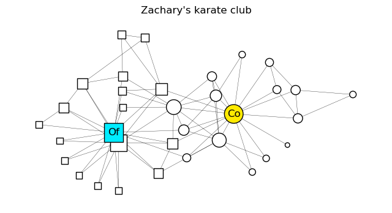

```python
karate = nx.karate_club_graph() # node['club'] = either 'Mr. Hi' or 'Officer'
for u, v in karate.edges():     # these unused weights quantify the
    del karate[u][v]['weight']  # frequency of two people's interaction
karate.nodes[8]['club'] = 'Officer' # NetworkX's record differs from Newman's
karate.graph['parts'                # the natural partitions
            ] = nx.utils.groups(dict(karate.nodes('club')))
karate.graph['degs'] = nx.degree_centrality(karate)
karate.graph['pos'] = {n: c[::-1] for n, c in
                       nx.kamada_kawai_layout(karate).items()}

print('Number of nodes:', karate.number_of_nodes())
print('Number of edges:', karate.number_of_edges())

def karate_plot(title, node_color, **kwargs):
    plt.figure(figsize=(8, 4))
    plt.title(title)
    nx.draw(karate, pos=karate.graph['pos'],     # draw the edges only
            node_size=0, width=.25)
    for i, part in enumerate(karate.graph['parts'].values()):
        nx.draw(karate, pos=karate.graph['pos'], # draw the nodes only
                width=0, edgecolors='k',
                labels={33: 'Of'} if i else {0: 'Co'},
                node_size=[k*1000 if n in part else 0
                           for n, k in karate.graph['degs'].items()],
                node_shape='s' if i else 'o',
                node_color=node_color, **kwargs)
karate_plot('Zachary\'s karate club', [yellow]+[white]*32+[cyan])
```

### Dolphins.

The second real network is the social network of a group of dolphins (Lusseau et al., 2003), on which an edge denotes two dolphins' frequent interaction.

Some biologists had been recording 62 dolphins' behaviours in New Zealand for some years, but a dolphin (SN100, the purple triangle) suddenly left others. The biologists observed that the dolphins' community subsequently split into two (circles and squares).

You can download the dataset [here](http://www-personal.umich.edu/~mejn/netdata/dolphins.zip).

```
Number of nodes: 62
Number of edges: 159
```

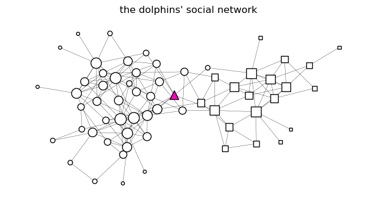

```python
dolphins = nx.read_gml('datasets/dolphins.gml')
for n, d in dolphins.nodes(True):
    d['group'] = n in [ # names of the dolphins in one of the two groups
        'Beescratch', 'DN16', 'DN21', 'DN63', 'Feather',
        'Gallatin', 'Jet', 'Knit', 'MN23', 'Mus',
        'Notch', 'Number1', 'Quasi', 'Ripplefluke', 'SN90',
        'TR82', 'Upbang', 'Wave', 'Web', 'Zig']
dolphins.nodes['SN100']['group'] = None # it left and broke the network
dolphins.graph['parts'] = nx.utils.groups(dict(dolphins.nodes('group')))
dolphins.graph['degs'] = nx.degree_centrality(dolphins)
dolphins.graph['pos'] = {n: c[::-1] for n,c in
                         nx.kamada_kawai_layout(dolphins).items()}

print('Number of nodes:', dolphins.number_of_nodes())
print('Number of edges:', dolphins.number_of_edges())

def dolphins_plot(title, node_color, **kwargs):
    plt.figure(figsize=(8, 4))
    plt.title(title)
    nx.draw(dolphins, pos=dolphins.graph['pos'], node_size=0, width=.25)
    for i, part in dolphins.graph['parts'].items():
        nx.draw(dolphins, pos=dolphins.graph['pos'], width=0, edgecolors='k',
                node_size=[k*1000 if n in part else 0
                           for n, k in dolphins.graph['degs'].items()],
                node_shape={0: 'o', 1: 's', None: '^'}[i],
                node_color=node_color, **kwargs)
dolphins_plot('the dolphins\' social network',
              [magenta if b is None else white
               for n, b in dolphins.nodes('group')])
```

# 1. Cut size minimization

We would like to split a network into two partitions to reduce the edges connecting them as much as possible. The number of these edges is called the "cut size" as the networks is broken once they are removed. The problem of cut size minimization particularly interests electronic engineers because they must divide a large circuit into several smaller and more manageable parts for industrial manufacture.

## 1.1 The Kernighan-Lin algorithm

The Kernighan-Lin algorithm is the standard solution to the problem ([Kernighan and Lin, 1970](https://ieeexplore.ieee.org/document/6771089)).

1. Given the required sizes of the partitions, the algorithm first divides the network into two arbitrary partitions.
2. It computes each node's **gain**, i.e. contribution to the cut size. A node's gain is defined as $G=E-I$ when it connects to $E$ nodes outside its partition and $I$ nodes outside.
3. It swaps the pair of nodes that reduces the cut size the most. Swapping nodes $i$ and $j$ causes a cut size change $\Delta_{ij}=G_i+G_j-2n_{ij}$, where $i$ and $j$ share $n_{ij}$ neighbours. If no pair reduces the cut size (i.e. $\Delta_{ij}>0$ for all pairs), it swaps the pair that increases the cut size the least.
4. After one swap, the algorithm freezes the swapped nodes so that they will not be swapped again.
5. It repeats steps 2 to 4 until all nodes are frozen.

The whole procedure to swap all nodes once is called one pass. The standard Kernighan-Lin algorithm goes through multiple passes until the cut size increases after a pass.

You may try to implement it as a programming exercise, but it is not easy. Luckily, NetworkX has implemented it for us, and you can call it with `community.kernighan_lin_bisection`.

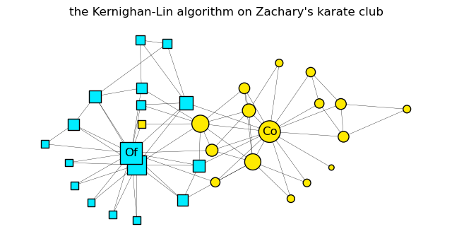

```python
for i, b in enumerate(nx.community.kernighan_lin_bisection(karate, seed=5056)):
    for n in b: karate.nodes[n]['KL'] = i
karate_plot('the Kernighan-Lin algorithm on Zachary\'s karate club',
            [yellow if b==karate.nodes[0]['KL'] else cyan
             for n, b in karate.nodes('KL')])
```

The Kernighan-Lin algorithm seems to be able to divide the karate club accurately. On the contrary, communities in the dolphins' social network hardly correspond to bipartitions that have a small cut size.

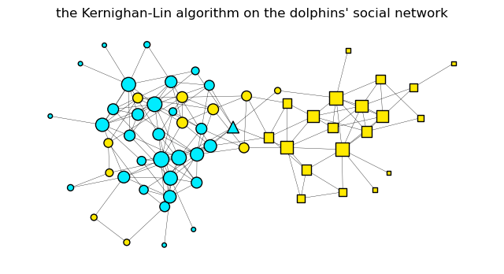

```python
for i, b in enumerate(nx.community.kernighan_lin_bisection(dolphins, seed=5056)):
    for n in b: dolphins.nodes[n]['KL'] = i
dolphins_plot('the Kernighan-Lin algorithm on the dolphins\' social network',
              [cyan if b else yellow for n, b in dolphins.nodes('KL')])
```

## 1.2 Spectral partitioning

The problem of cut size minimization can be reformulated in terms of the eigenvalues and eigenvectors of a network's Laplacian matrix ([Newman, 2006](https://journals.aps.org/pre/abstract/10.1103/PhysRevE.74.036104)). Let $\lambda_i$ be its $i$th smallest eigenvalue and $\mathbf{v}_i$ be its corresponding eigenvector. While $\lambda_1\equiv0$ and $\mathbf{v}_1\equiv\mathbf{1}$, signs of the elements in $\mathbf{v}_2$ can divide the network into two partitions that reduce the cut size.

The vector $\mathbf{v}_2$ is often referred to as *the Fiedler vector* because the method was first proposed by [Fiedler (1973)](https://dml.cz/handle/10338.dmlcz/101168).

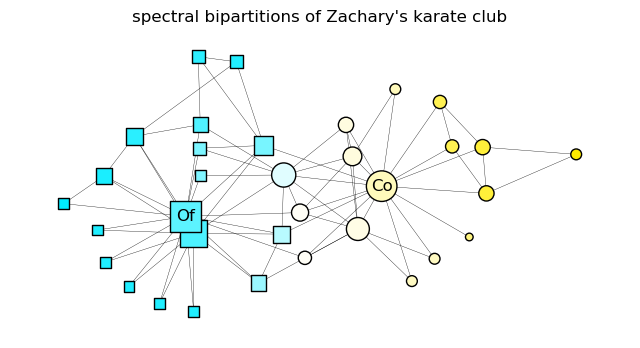

```python
ywc = mpl.colors.LinearSegmentedColormap.from_list('', [yellow, white, cyan])
vmin, vmax = 0, 0
for n, b in enumerate(np.linalg.eigh(
    nx.laplacian_matrix(karate).toarray())[1][:, 1]):
    karate.nodes[n]['spectral'] = b
    if b < vmin: vmin = b
    elif b > vmax: vmax = b
colour_fix = 1 if karate.nodes[0]['spectral']<0 else -1
karate_plot('spectral bipartitions of Zachary\'s karate club',
            [-b/vmin*colour_fix if b<0 else b/vmax*colour_fix
             for n, b in karate.nodes('spectral')], cmap=ywc)
```

In fact, magnitudes of the elements in $\mathbf{v}_2$ may be understood as a node's "affinity" with its partition. The larger magnitude $\left(\mathbf{v}_2\right)_i$ has, the more likely $i$ belongs to its partition. Hence, if sizes of the partitions are given, say $n$ versus $\left({N-n}\right)$, one should group the $n$ nodes represented by the $n$ most positive elements in $\mathbf{v}_2$ into the same partition and leave the others in the other partition.

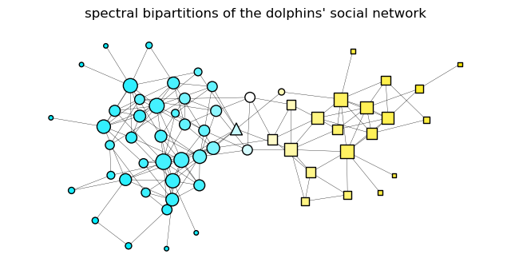

```python
vmin, vmax = 0, 0
for n, b in enumerate(np.linalg.eigh(
    nx.laplacian_matrix(dolphins).toarray())[1][:, 1]):
    dolphins.nodes[list(dolphins)[n]]['spectral'] = b
    if b < vmin: vmin = b
    elif b > vmax: vmax = b
dolphins_plot('spectral bipartitions of the dolphins\' social network',
              [-b/vmin if b<0 else b/vmax
               for n, b in dolphins.nodes('spectral')], cmap=ywc)
```

# 2. Hierarchical clustering

We can translate a network into a hierarchy of "intimacy" by bipartitioning it iteratively. Two nodes are close in the hierarchy if they are likely to belong to the same partition. This idea is generally called "hierarchical clustering".

There are two ways to build such a hierarchy, viz. a **bottom-up** approach and a **top-down** approach. The former iteratively group nodes into larger partitions until all nodes belong to one partition, whereas the latter iteratively divides the network into two until all nodes are isolated.

I am now going to demonstrate the idea using a small toy network. Intuitively, nodes {0, 1, 2} should belong to the same partition, so should {3, 4, 5} and {6, 7, 8, 9}, but it becomes ambiguous for node 10.

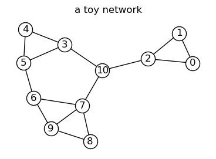

```python
toy = nx.disjoint_union_all(
    [nx.cycle_graph(3), nx.cycle_graph(3), nx.cycle_graph(4)])
toy.add_edges_from([(10, v) for v in [2, 3, 7]] + [(5, 6), (7, 9)])

plt.figure(figsize=(4.5, 3))
plt.title('a toy network')
nx.draw_kamada_kawai(toy, node_color='w', edgecolors='k', with_labels=True)
```

I will also use a social network of workers.

### Striking workers' trade union.

The third real network in this tutorial is the trade union of some striking workers (De Nooy et al., 2005). There are 4 young Spanish speakers (yellow sawtooth), 9 young English speakers (white sawtooth), and 11 old English speakers (white round). An edge between two workers indicates that they often talked about the strike to each other.

The company tried to resolve the strike by negotiating with Sam and Wendle (thick border), but they found this strategy completely ineffective.

```
Number of nodes: 24
Number of edges: 38
```

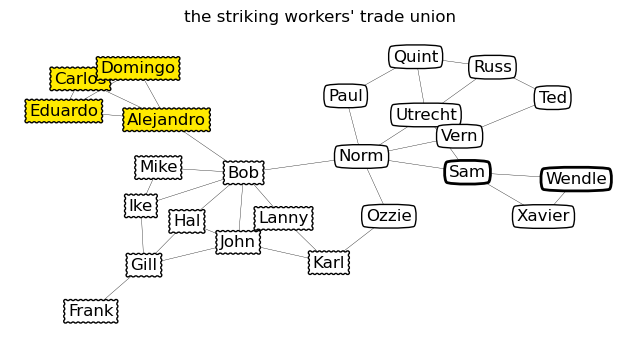

```python
strike = nx.Graph()
strike.add_edges_from(
    [( 1,11), ( 1,15), ( 2, 5), ( 2, 7), ( 2,10), ( 2,15), ( 3,17), ( 4,20),
     ( 4,21), ( 4,23), ( 5, 9), ( 5,12), ( 5,15), ( 5,16), ( 5,22), ( 6, 9),
     ( 6,17), ( 6,24), ( 7,10), ( 7,14), ( 8,12), ( 8,18), ( 8,24), ( 9,13),
     ( 9,18), ( 9,19), ( 9,21), ( 9,24), (10,22), (11,15), (13,17), (13,19),
     (14,16), (17,24), (18,24), (20,21), (20,23), (21,23)])
strike = nx.relabel_nodes(strike, {i+1: n for i, n in enumerate(
    ['Xavier', 'Utrecht', 'Frank', 'Domingo', 'Norm', 'Hal', 'Russ', 'Karl',
     'Bob', 'Quint', 'Wendle', 'Ozzie','Ike', 'Ted', 'Sam', 'Vern',
     'Gill', 'Lanny', 'Mike', 'Carlos', 'Alejandro', 'Paul', 'Eduardo', 'John'])})

for n, d in strike.nodes(True):
    d['lang'] = ('Spanish' if n in ['Carlos', 'Domingo',
                                    'Eduardo', 'Alejandro'] else 'English')
    d['old'] = n in ['Ozzie', 'Norm', 'Paul', 'Quint', 'Russ', 'Ted',
                     'Utrecht', 'Vern', 'Sam', 'Wendle', 'Xavier']
    d['negotiator'] = n in ['Sam', 'Wendle']
    d['bbox'] = (yellow if d['lang'] == 'Spanish' else white,
                 'round4' if d['old'] else 'roundtooth',
                 2 if d['negotiator'] else 1)
strike.graph['pos'] = nx.kamada_kawai_layout(strike)

print('Number of nodes:', strike.number_of_nodes())
print('Number of edges:', strike.number_of_edges())

plt.figure(figsize=(8, 4))
plt.title('the striking workers\' trade union')
nx.draw(strike, pos=strike.graph['pos'], node_size=0, width=.25)
for bbox, N in nx.utils.groups(dict(strike.nodes('bbox'))).items():
    labels = {n: n for n in N}
    nx.draw(strike, pos=strike.graph['pos'],
            node_size=0, width=0, labels=labels,
            bbox=dict(fc=bbox[0], boxstyle=bbox[1], lw=bbox[2]))
```

## 2.1 The Ravasz algorithm

In particular, Ravasz et al. use a similarity measure called "overlap coefficient". Given an adjacency matrix $\mathbf{A}$ and degrees $\left\{k\right\}$, the overlap coefficient between nodes $i$ and $j$ reads

\begin{align} \omega_{ij}=\dfrac{n_{ij}+A_{ij}} {\min{\left(k_i,k_j\right)}+1-A_{ij}}\,, \end{align}

when $i$ and $j$ share $n_{ij}$ neighbours.

The Ravasz algorithm uses a bottom-up approach. It first treats all nodes as individual partitions, then it iteratively groups the most similar partitions.

```python
def overlap_coefficient(G, i, j):
    a = int(G.has_edge(i, j))
    ki, kj = G.degree(i), G.degree(j)
    return ( (len(list(nx.common_neighbors(G, i, j)))+a)
            /(min(ki, kj)+1-a))

def similarity(G, P, Q):
    S = [[overlap_coefficient(G, p, q) for q in Q] for p in P]
    return np.mean(S)

def ravasz(G):
    hierarchy = [{n} for n in G]
    while len(hierarchy) > 1:
        yield tuple(hierarchy)
        L = len(hierarchy)
        S = -np.ones((L, L), float)
        for i in range(L):
            for j in range(i):
                S[i, j] = similarity(G, hierarchy[i], hierarchy[j])
        am = S.argmax()
        i, j = am % L, am // L
        hierarchy[i] = hierarchy[i].union(hierarchy[j])
        del hierarchy[j]

toy.graph['ravasz'] = list(ravasz(toy))
print('The Ravasz algorithm on the toy network:')
toy.graph['ravasz']
```

```
The Ravasz algorithm on the toy network:
```

```
[({0}, {1}, {2}, {3}, {4}, {5}, {6}, {7}, {8}, {9}, {10}),
 ({0, 1}, {2}, {3}, {4}, {5}, {6}, {7}, {8}, {9}, {10}),
 ({0, 1, 2}, {3}, {4}, {5}, {6}, {7}, {8}, {9}, {10}),
 ({0, 1, 2}, {3, 4}, {5}, {6}, {7}, {8}, {9}, {10}),
 ({0, 1, 2}, {3, 4}, {5}, {6}, {7, 8}, {9}, {10}),
 ({0, 1, 2}, {3, 4}, {5}, {6}, {7, 8, 9}, {10}),
 ({0, 1, 2}, {3, 4, 5}, {6}, {7, 8, 9}, {10}),
 ({0, 1, 2}, {3, 4, 5}, {6, 7, 8, 9}, {10}),
 ({0, 1, 2, 10}, {3, 4, 5}, {6, 7, 8, 9}),
 ({0, 1, 2, 10}, {3, 4, 5, 6, 7, 8, 9})]
```

The Ravasz algorithm assigns node 10 of the toy network into the group of nodes {0, 1, 2}. However, as you may see, the performance of the algorithm highly depends on the input order of the nodes. For example, suppose nodes $s$, $t$, $u$, and $v$ are pairwise similar. When the algorithm bipartitions them, the algorithm probably returns $\left(\left\{s,t\right\},\left\{u,v\right\}\right)$ if I input $\left\{s,t,u,v\right\}$ but $\left(\left\{s,u\right\},\left\{t,v\right\}\right)$ if I input $\left\{s,u,t,v\right\}$.

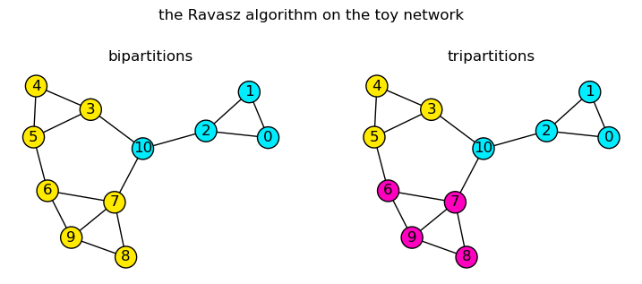

```python
plt.figure(figsize=(9, 3))

plt.subplot(121)
plt.gcf().suptitle('the Ravasz algorithm on the toy network', y=1.1)
plt.title('bipartitions')
nx.draw_kamada_kawai(
    toy, edgecolors='k', with_labels=True,
    node_color=[cyan if n in toy.graph['ravasz'][-1][0] else yellow for n in toy])

plt.subplot(122)
plt.title('tripartitions')
nx.draw_kamada_kawai(
    toy, edgecolors='k', with_labels=True,
    node_color=[cyan if n in toy.graph['ravasz'][-2][0] else (
        yellow if n in toy.graph['ravasz'][-2][1] else magenta) for n in toy])
```

### Dendrogram.

A hierarchy can be clearly illustrated with a dendrogram. You can draw it with `scipy.cluster.hierarchy.dendrogram`, but its usage is quite complicated.

To draw the hierarchy of an $N$-node network, the method requires a **linkage matrix** $\mathbf{Z}_{\left(N-1\right) \times 4}$. Each row of the matrix represents a **join**: at the $i$th join, partitions with indices $Z_{i1}$ and $Z_{i2}$ group to form a partition with $Z_{i4}$ nodes, and $Z_{i3}$ marks the height of the join in the dendrogram.

Please read the method's [documenation](https://docs.scipy.org/doc/scipy/reference/generated/scipy.cluster.hierarchy.dendrogram.html#scipy.cluster.hierarchy.dendrogram) for more information.

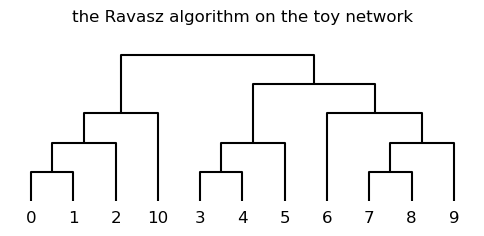

```python
from scipy.cluster import hierarchy

def to_linkage(tuples_of_sets, height='rank'):
    N = len(tuples_of_sets[0])
    Z = np.zeros((N-1, 4), float)
    record = list(tuples_of_sets[0])

    for i in range(N-2):
        idxs, sets = [], []
        for set_ in tuples_of_sets[i]:
            if set_ not in tuples_of_sets[i+1]:
                idxs.append(record.index(set_))
                sets.append(set_)
        record += [sets[0].union(sets[1])]
        Z[i, :2], Z[i, -1] = idxs, len(record[-1])
    Z[-1] = [*[record.index(set_) for set_ in tuples_of_sets[-1]], 0, N]

    if height == 'rank':
        track = sorted(list(set(Z[:, 3])))
        Z[:, 2] = [track.index(Z[i, 3])+1 for i in range(N-1)]
    else: # height == 'size'
        Z[:, 2] = Z[:, 3]-1
    return Z

plt.figure(figsize=(6, 2))
plt.title('the Ravasz algorithm on the toy network\n')
hierarchy.dendrogram(to_linkage(toy.graph['ravasz'], height='rank'),
                     color_threshold=0, above_threshold_color='k')
plt.gca().yaxis.set_visible(False)
for spine in plt.gca().spines.values(): spine.set_visible(False)
```

You may actually implement the Ravasz algorithm with `scipy.cluster.hierarchy.linkage`, which is, however, as complicated as other methods of SciPy. The following dendrogram is generated with the SciPy-based Ravasz algorithm and identical to the previous one despite different positions of nodes.

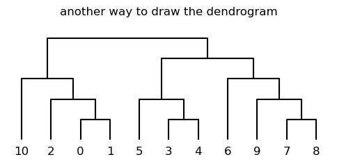

```python
def overlap_distance(Li, Lj): # two nodes' laplacian vectors
    i, j = np.argmax(Li>0), np.argmax(Lj>0)
    ki, kj = Li[i], Lj[j]
    Ai, Aj = -Li, -Lj; Ai[i], Aj[j] = 0, 0
    nij = np.sum(Ai*Aj)
    overlap_coefficient = (nij+Ai[j])/(min(ki, kj)+1-Ai[j])
    return 1-overlap_coefficient # hence dissimilarity

Z = hierarchy.linkage(nx.laplacian_matrix(toy).toarray(),
                      method='average', metric=overlap_distance)
track = sorted(list(set(Z[:, 3])))
Z[:, 2] = [track.index(Z[i, 3])+1 for i in range(Z.shape[0])]

plt.figure(figsize=(6, 2))
plt.title('another way to draw the dendrogram\n')
hierarchy.dendrogram(Z, color_threshold=0, above_threshold_color='k')
plt.gca().yaxis.set_visible(False)
for spine in plt.gca().spines.values(): spine.set_visible(False)
```

Lastly, I apply the Ravasz algorithm on the the trade union. The algorithm can tripartition the network into a group of Spanish speakers, a group of young English speakers, and a group of old English speakers.

By the way, avoid plotting a large network's dendrogram, which looks quite clumsy because of its numerous nodes.

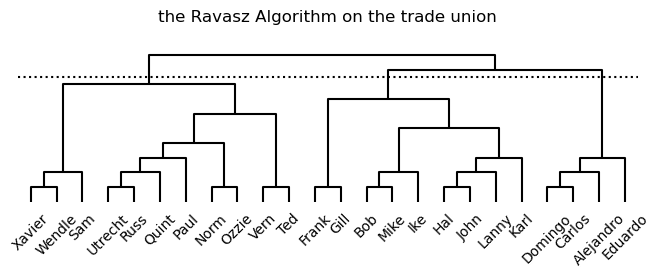

```python
strike.graph['ravasz'] = list(ravasz(strike))
plt.figure(figsize=(8, 2))
plt.title('the Ravasz Algorithm on the trade union\n')
hierarchy.dendrogram(to_linkage(strike.graph['ravasz']), labels=list(strike),
                     color_threshold=0, above_threshold_color='k')
plt.axhline(8.5, c='k', ls=':')
plt.gca().yaxis.set_visible(False)
for spine in plt.gca().spines.values(): spine.set_visible(False)
```

## 2.2 The Girvan-Newman algorithm

The Girvan-Newman algorithm, in contrast, employs a top-down approach. It keeps dividing a network into two by successively deleting the most important edge ([Girvan and Newman, 2002](https://www.pnas.org/doi/10.1073/pnas.122653799)).

Which edge is the most important in the network, though? Girvan and Newman consider the betweenness of nodes and generalizes it for edges: an important edge is traversed by many paths and thus have a high **edge betweenness**. Formally, the edge betweenness $b{\left(e\right)}$ of an edge $e$ reads

\begin{align} b{\left(e\right)} \sim \sum_{s<t}{\dfrac{g_{st}{\left(e\right)}} {g_{st}}}\,, \end{align}

where $g_{st}$ counts the shortest paths between nodes $s$ and $t$ and $g_{st}{\left(e\right)}$ similarly counts the ones that traverse $e$. The edge betweenness of edges is recalculated after deleting each edge.

You may call the Girvan-Newman algorithm with `community.girvan_newman`.

```python
toy.graph['GN'] = list(nx.community.girvan_newman(toy))[::-1]
print('The Girvan-Newman algorithm on the toy network:')
toy.graph['GN']
```

```
The Girvan-Newman algorithm on the toy network:
```

```
[({0}, {1}, {2}, {3}, {4}, {5}, {6}, {7}, {8}, {9}, {10}),
 ({0}, {1}, {2}, {3}, {4}, {5}, {6}, {7}, {8, 9}, {10}),
 ({0}, {1}, {2}, {3}, {4}, {5}, {6}, {7, 8, 9}, {10}),
 ({0}, {1}, {2}, {3}, {4, 5}, {6}, {7, 8, 9}, {10}),
 ({0}, {1}, {2}, {3, 4, 5}, {6}, {7, 8, 9}, {10}),
 ({0}, {1, 2}, {3, 4, 5}, {6}, {7, 8, 9}, {10}),
 ({0, 1, 2}, {3, 4, 5}, {6}, {7, 8, 9}, {10}),
 ({0, 1, 2}, {3, 4, 5}, {6, 7, 8, 9}, {10}),
 ({0, 1, 2}, {3, 4, 5, 10}, {6, 7, 8, 9}),
 ({0, 1, 2}, {3, 4, 5, 6, 7, 8, 9, 10})]
```

While the Ravasz algorithm puts node 10 in the group of nodes {0, 1, 2}, the Girvan-Newman algorithm puts it in the group of nodes {3, 4, 5} when it tripartitions the toy network.

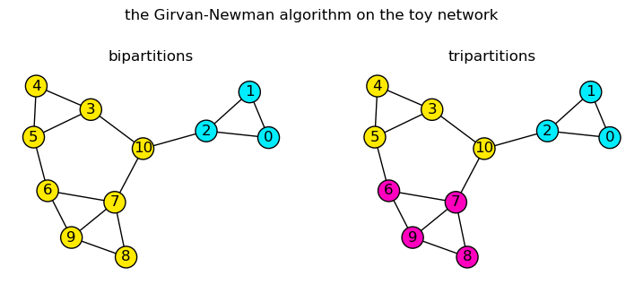

```python
plt.figure(figsize=(9, 3))

plt.subplot(121)
plt.gcf().suptitle('the Girvan-Newman algorithm on the toy network', y=1.1)
plt.title('bipartitions')
nx.draw_kamada_kawai(
    toy, edgecolors='k', with_labels=True,
    node_color=[cyan if n in toy.graph['GN'][-1][0] else yellow for n in toy])

plt.subplot(122)
plt.title('tripartitions')
nx.draw_kamada_kawai(
    toy, edgecolors='k', with_labels=True,
    node_color=[cyan if n in toy.graph['GN'][-2][0] else (
        yellow if n in toy.graph['GN'][-2][1] else magenta) for n in toy])
```

Again, you may plot a dendrogram to clearly visualize the hierarchy.

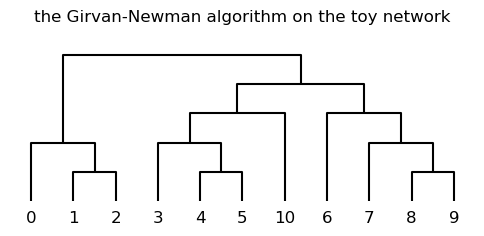

```python
plt.figure(figsize=(6, 2))
plt.title('the Girvan-Newman algorithm on the toy network\n')
hierarchy.dendrogram(to_linkage(toy.graph['GN'], height='rank'),
                     color_threshold=0, above_threshold_color='k')
plt.gca().yaxis.set_visible(False)
for spine in plt.gca().spines.values(): spine.set_visible(False)
```

It is also able to divide the trade union into a group of Spanish speakers, a group of young English speakers, and a group of old English speakers.

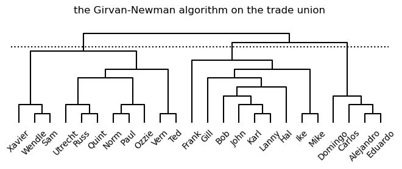

```python
strike.graph['GN'] = list(nx.community.girvan_newman(strike))[::-1]
plt.figure(figsize=(8, 2))
plt.title('the Girvan-Newman algorithm on the trade union\n')
hierarchy.dendrogram(to_linkage(strike.graph['GN']), labels=list(strike),
                     color_threshold=0, above_threshold_color='k')
plt.axhline(8.5, c='k', ls=':')
plt.gca().yaxis.set_visible(False)
for spine in plt.gca().spines.values(): spine.set_visible(False)
```

Finally, let us see how the Girvan-Newman algorithm perform on bipartitioning Zachary's karate club: only one node is misclassified. This impressive result helped spark researches on algorithms of community detection.

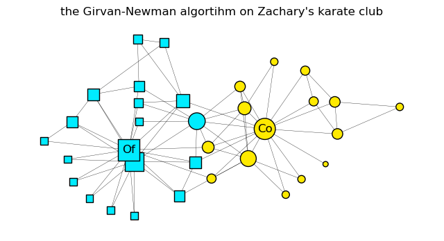

```python
karate_GN = next(nx.community.girvan_newman(karate))[0]
for n in range(karate.number_of_nodes()):
    karate.nodes[n]['GN'] = n in karate_GN
karate_plot('the Girvan-Newman algortihm on Zachary\'s karate club',
            [yellow if b==karate.nodes[0]['GN'] else cyan
             for n, b in karate.nodes('GN')])
```

# 3. From partitions to communities

So far we have only focused on graph partitioning because we are given the number of partitions and sometimes also their sizes. This is fundamentally different from community detection as we do not know the number of communities and their sizes in advance.

The problem of community detection inevitably raises a philosophical question: what is a "community"? There is no universal definition of "community" upon which everyone agrees. Still, we intuitively think that

- a community should be a dense subgraph and that
- a node links to nodes of the same community more frequently than to the ones outside.

We may therefore define a community with topological concepts like **cliques**, **components**, and **cores**.

- A $k$-clique is a $k$-node fully connected subgraph.
- A $𝑘$-component is a subgraph that remains connected unless $k$ nodes are removed from it.
- A $k$-core is a subgraph in which every node connects with $k$ nodes.

On the contrary, we often avoid defining a community but choose to measure how likely a given group of nodes represents a community using **modularity** $M$.

## 3.1 Modularity

Let $\left\{Q_1, Q_2, \dots, Q_p\right\}$ be a $p$-partition of an $E$-edge network, then suppose it assigns node $i$ to the partition $q_i$. The modularity of this way of partitioning reads

\begin{align} M = \dfrac{1}{2E} \sum_i{ \sum_j{ B_{ij}\,\delta{ \left(q_i, q_j\right) } } } \quad \text{for} \quad B_{ij} = A_{ij}-\dfrac{k_ik_j}{2E}\,, \end{align}

where $\mathbf{A}\equiv\left(A_{ij}\right)$ is the adjacency matrix and $k_i$ is the degree of $i$. Alternatively, one may write it in terms of matrix.

\begin{align} M = \dfrac{1}{2E} \text{tr}{ \left( \mathbf{C}^\top\,\mathbf{B}\,\mathbf{C} \right) }\,, \end{align}

where $\mathbf{B}\equiv\left(B_{ij}\right)$ is called the modularity matrix. You can obtain $\mathbf{B}$ with `modularity_matrix`. In the other matrix $\mathbf{C}$, its element $C_{is}=1$ if $i$ belongs to the $s$th partition (i.e. $q_i=Q_s$), otherwise $C_{is}=0$.

```python
def modularity(G, partitions):
    Qs = partitions
    E = G.number_of_edges()
    B = nx.modularity_matrix(G)
    C = np.array([[1 if i in Q else 0 for Q in Qs] for i in G])
    return np.trace(C.T@B@C) / (2*E)

(modularity(strike, strike.graph['GN'][-1]), # bipartition
 modularity(strike, strike.graph['GN'][-2])) # tripartition
```

```
(0.43490304709141275, 0.5481301939058172)
```

Furthermore, modularity can be reformulated as

\begin{align} M = \sum_Q {\left[ \dfrac{E_Q}{E} - \left(\dfrac{K_Q}{2E}\right)^2 \right]}\,, \end{align}

in which every partition $Q$ contains $E_Q$ edges and some nodes whose **total** degree is $K_Q$ on the **original** network. Hence, the modularity of a partition $Q$ can be defined as its contribution to the total modularity, i.e.

\begin{align} M_Q = \dfrac{E_Q}{E}-\left(\dfrac{K_Q}{2E}\right)^2\,. \end{align}

We can see two special cases here.

1. If all nodes are grouped as one single partition $Q$, $K_Q=2E$ and $E_Q=E$, yielding $M=M_Q=0$.
2. If every node is regarded as an individual partition, $E_Q\equiv0$ for all partitions, yielding $M<0$.

```python
def modularity_contribution(G, partition):
    E = G.number_of_edges()
    Q = nx.subgraph(G, partition)
    EQ = Q.number_of_edges()
    KQ = sum(G.degree[n] for n in Q)
    return EQ/E-(KQ/2/E)**2

(modularity_contribution(strike, strike.graph['GN'][-2][0]), # old English
 modularity_contribution(strike, strike.graph['GN'][-2][1]), # young English
 modularity_contribution(strike, strike.graph['GN'][-2][2])) # young Spanish
```

```
(0.2174515235457064, 0.20204293628808864, 0.12863573407202214)
```

## 3.2 Interpretation of modularity

The range of modularity is $M\in\left[-1, 1\right]$. The more $M$ approaches $1$ for $p$ partitions, the better they depict $p$ communities. The effectiveness of modularity relies on the fundamental hypothesis of community detection:

a random network lacks communities.

In fact, modularity compares a network to a random network that has the same degree sequence. Suppose that we are creating a random network.

- The degrees $\left\{k\right\}$ of the nodes are already fixed, so the number of edges $E=\frac{1}{2}\sum_ik_i$ is also fixed.
- As there are $E$ edges, there are $2E$ **stubs**, i.e. ends of edges.
- Assuming that the network permits self-loops and multiple edges between two nodes, a stub of node $i$ may link to a stub of node $j$ with probability $\dfrac{k_j}{2E-1}$.
- Since $i$ has $k_i$ stubs, we expect that there are $\dfrac{k_ik_j}{2E-1}\approx\dfrac{k_ik_j}{2E}$ edges between $i$ and $j$. In other words, $\dfrac{k_ik_j}{2E}$ is the probability of an edge $\left(i, j\right)$ on a random network.

Therefore, if $M\sim\sum{\left(A_{ij}-\dfrac{k_ik_j}{2E}\right)}>0$, a partition has more edges than by chance, so it is "unexpectedly dense". While we believe that a community is a dense subgraph, the fundamental hypothesis sets the density of a **random network** as the benchmark: if a subgraph is denser than its random counterpart, we tend to believe that it represents a community.

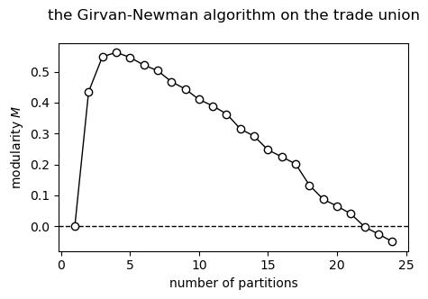

```python
plt.figure(figsize=(5, 3))
plt.axhline(0, c='k', ls='--', lw=1)

M = {len(Qs): modularity(strike, Qs) for Qs in strike.graph['GN']}
M[1] = modularity(strike, (set(strike),))
plt.plot(M.keys(), M.values(), 'ko-', mfc='w', lw=1)

plt.xlabel('number of partitions')
plt.ylabel('modularity $M$')
plt.title('the Girvan-Newman algorithm on the trade union\n')
plt.show()
```

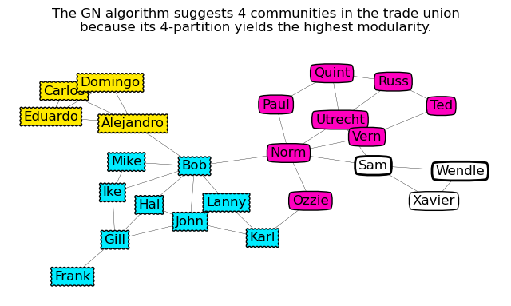

```python
optimal = max(M, key=lambda p: M[p])
for p, Q in enumerate(strike.graph['GN'][-optimal+1]):
    if 'Sam' in Q or 'Alejandro' in Q: continue
    c = cyan if 'Bob' in Q else magenta
    for n in Q:
        bbox = list(strike.nodes[n]['bbox'])
        strike.nodes[n]['bbox'] = (c, *bbox[1:])


plt.figure(figsize=(8, 4))
plt.title('The GN algorithm suggests %d communities in the trade union\n' % optimal
         +'because its %d-partition yields the highest modularity.\n' % optimal)
nx.draw(strike, pos=strike.graph['pos'], node_size=0, width=.25)
for bbox, N in nx.utils.groups(dict(strike.nodes('bbox'))).items():
    labels = {n: n for n in N}
    nx.draw(strike, pos=strike.graph['pos'],
            node_size=0, width=0, labels=labels,
            bbox=dict(fc=bbox[0], boxstyle=bbox[1], lw=bbox[2]))
```

# 4. Modularity maximization

Although there is no agreement upon the definition of a community, scientists commonly agree that modularity well assesses a potential community. Various new algorithms have been devised to maximize it after Girvan and Newman first succeeded.

### Network scientists' collaboration network.

The final real network this tutorial uses is the collaboration network of over a thousand network scientists ([Newman, 2006](https://journals.aps.org/pre/abstract/10.1103/PhysRevE.74.036104)). An edge connects two scientists who have at least coauthored once. While the original network is unconnected, I will only use its largest component, which contains 379 network scientists. You can download the dataset [here](http://www-personal.umich.edu/~mejn/netdata/netscience.zip).

```python
netscience = nx.read_gml('datasets/netscience.gml')
largestComponent = sorted(list(
    max(nx.connected_components(netscience), key=len)))
netscience_ = nx.Graph()
netscience_.add_nodes_from(largestComponent)
for i in range(len(largestComponent)):
    for j in range(i):
        u, v = largestComponent[i], largestComponent[j]
        if netscience.has_edge(u, v): netscience_.add_edge(u, v)
netscience = netscience_.copy()
del netscience_

# you may use "netscience.subgraph(largestComponent)" instead
# but it shuffles the order of nodes undesirably

netscience.graph['pos'] = nx.kamada_kawai_layout(netscience)
netscience.graph['degs'] = nx.degree_centrality(netscience)

print('Number of nodes:', netscience.number_of_nodes())
print('Number of edges:', netscience.number_of_edges())
```

```
Number of nodes: 379
Number of edges: 914
```

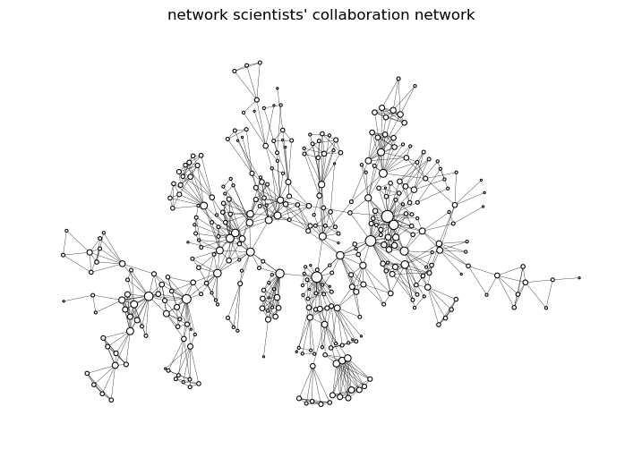

```python
def netscience_plot(title, node_color):
    plt.figure(figsize=(9, 6))
    plt.title(title)
    nx.draw(netscience, pos=netscience.graph['pos'],
            width=.25, edgecolors='k', linewidths=.75,
            node_size=[k*1000 for k in netscience.graph['degs'].values()],
            node_color=node_color)
netscience_plot('network scientists\' collaboration network', 'w')
```

## 4.1 The Newman algorithm and the Clauset-Newman-Moore alogirhtm

(Newman again.)

The Newman algorithm initially puts every node into a distinct partition, then it iteratively groups the two partitions that increase $M$ the most ([Newman, 2004](https://journals.aps.org/pre/abstract/10.1103/PhysRevE.69.066133)). Finally, the $k$-partition that yields the highest modularity is deemed the optimal partition. The idea is simple, and you can implement it easily, but it is computationally expensive: its running time costs $O{\left(EN+N^2\right)}$.

Later, Newman improved his algorithm with Clauset and Moore and invented the Clauset-Newman-Moore algorithm ([Clauset et al., 2004](https://journals.aps.org/pre/abstract/10.1103/PhysRevE.70.066111)), which only costs $O{\left(N\log^2{N}\right)}$. You can use it by calling `community.greedy_modularity_communities`.

```
Number of communities: 19
```

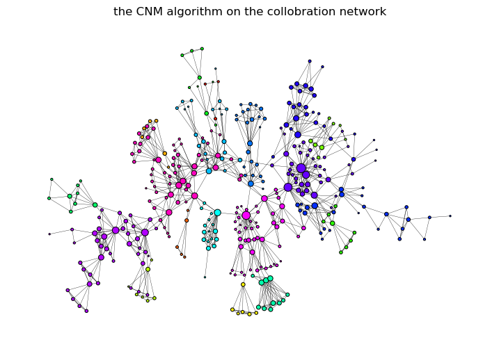

```python
netscience.graph['CNM'] = nx.community.greedy_modularity_communities(netscience)
for c, community in enumerate(netscience.graph['CNM']):
    for n in community: netscience.nodes[n]['CNM'] = c
cNum = c+1
netscience_plot('the CNM algorithm on the collobration network',
                [cmap(c/cNum) for n, c in netscience.nodes('CNM')])
print('Number of communities:', cNum)
```

The following community diagram simplifies the one above. A node represents a community, and its size grows with the number of its members. A node's border width indicates the number of its **intra**-community edges, whereas the weight of an edge indicates the number of **inter**-community edges.

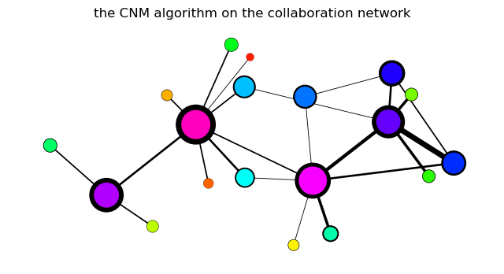

```python
def community_network(G, algorithm):

    def edges_between(G, U, V):
        return sum(sum(G.has_edge(u, v) for u in U) for v in V)

    G_ = nx.Graph()
    for i, Q in enumerate(G.graph[algorithm]):
        intra = nx.subgraph(G, Q).number_of_edges()
        G_.add_node(i, size=len(Q), loop=intra)
    for i in G_:
        for j in range(i):
            inter = edges_between(
                G,G.graph[algorithm][i], G.graph[algorithm][j])
            if inter > 0: G_.add_edge(i, j, weight=inter)
    G_.graph['pos'] = {i: np.mean(
        [G.graph['pos'][n] for n in G.graph[algorithm][i]], axis=0) for i in G_}
    return G_

def community_diagram(G_, title, node_color):
    sizes = np.array([s for n, s in G_.nodes('size')])
    loops = np.array([l for n, l in G_.nodes('loop')])
    weights = np.array([w for u, v, w in G_.edges(data='weight')])

    plt.figure(figsize=(8, 4))
    plt.title(title)
    nx.draw(G_, pos=G_.graph['pos'], edgecolors='k',
            node_color=node_color,
            node_size=sizes/sizes.max()*1000,
            linewidths=loops/loops.max()*5,
            width=weights/weights.max()*5)

netscience_CNM = community_network(netscience, 'CNM')
community_diagram(netscience_CNM,
                  'the CNM algorithm on the collaboration network',
                  [cmap(c/cNum) for c in netscience_CNM])
```

As a comparison, here I also apply the Girvan-Newman algorithm, whose running time costs $O{\left(N^3\right)}$, on the collaboration network.

```
Number of communities: 18
```

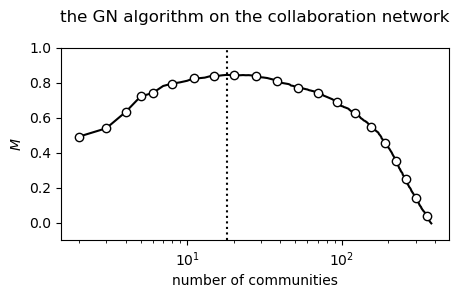

```python
# this block is slow
modularities = [modularity(netscience, Qs)
                for Qs in nx.community.girvan_newman(netscience)]
GN = nx.community.girvan_newman(netscience)
cNum = modularities.index(max(modularities))+2
for i in range(cNum-2): next(GN)
netscience.graph['GN'] = next(GN)

plt.figure(figsize=(5, 2.5))
plt.semilogx(range(2, len(modularities)+2), modularities,
             'ko-', mfc='w', markevery=.05)
plt.axvline(cNum, c='k', ls=':')
plt.xlabel('number of communities')
plt.ylabel('$M$'); plt.ylim(-.1, 1)
plt.title('the GN algorithm on the collaboration network\n')

print('Number of communities:', cNum)
```

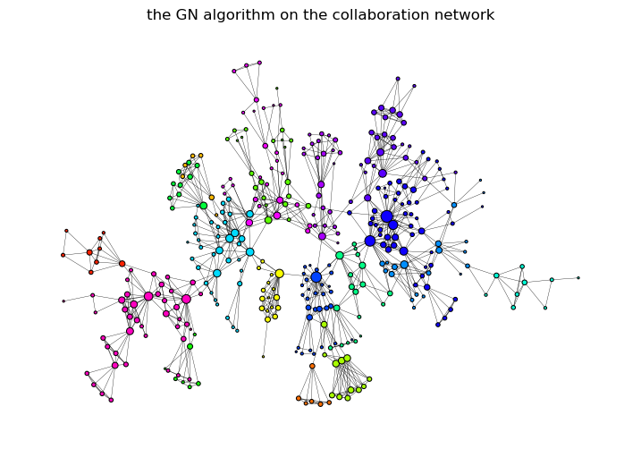

```python
for c, community in enumerate(netscience.graph['GN']):
    for n in community: netscience.nodes[n]['GN'] = c
cNum = c+1
netscience_plot('the GN algorithm on the collaboration network',
                [cmap(c/cNum) for n, c in netscience.nodes('GN')])
```

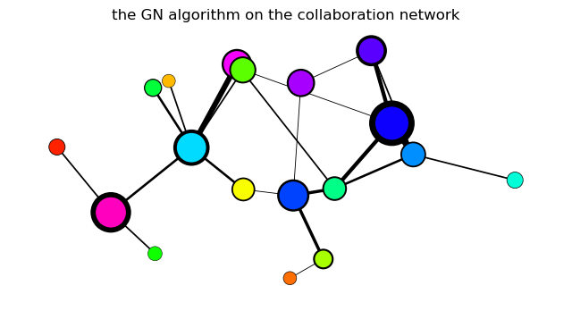

```python
netscience_GN = community_network(netscience, 'GN')
community_diagram(netscience_GN,
                  'the GN algorithm on the collaboration network',
                  [cmap(c/cNum) for c in netscience_GN])
```

## 4.2 The Louvain algorithm

Blonde et al., who all come from the University of Louvain, Belgium, proposed the Louvain Algorithm, which maximizes modularity with a running time in $O{\left(N\log{N}\right)}$ ([Blondel, 2008](https://iopscience.iop.org/article/10.1088/1742-5468/2008/10/P10008)).

After assigning every node into a different community, the Louvain algorithm iteratively does the following steps.

1. Move node $i$ to the community of one of its neighbours $j$ so that the resultant change in modularity $\Delta_{ij}$ is positive and maximized. If $\Delta_{ij}<0$ for all $j$, do not move $i$.
2. Repeat step 1 for all nodes sequentially until $\Delta_{ij}<0$ for all pairs of $\left(i, j\right)$.
3. Transform the original network to a weighted network, in which each node represents a proposed community. The inter-community edges becomes weighted edges between nodes, whereas the intra-community edges become weighted self-loops. (The weights are the number of the corresponding edges.)

The three steps form one pass, and the algorithm terminates once the network remains unchanged after step 3. The nodes of the final weighted network represent the potential communities.

Let nodes $i$ and $j$ belong to communities $I$ and $J$ before a move. The change in modularity $\Delta_{ij}=\Delta_I^{-i}+\Delta_J^{+i}$ is the sum of the change $\Delta_I^{-i}$ due to removing $i$ from $I$ and the change $\Delta_J^{+i}$ due to adding $i$ to $J$. When the weighted network has a total weight $W$,

\begin{align} \Delta_J^{+i} = \dfrac{k_i^J}{W} - {\left({\dfrac {w_J+k_i}{2W}}\right)}^2 + \left({\dfrac{w_J}{2W}}\right)^2 + \left({\dfrac{k_i}{2W}}\right)^2 \,, \end{align}

where $k_i$ is the total weight of $i$'s edges (i.e. its weighted degree) and $k_i^J$ is the total weight of $i$'s edges linking to nodes in $J$. Then, $w_J=\sum_{j\in J}{k_j}$. Finally, $\Delta_I^{-i}=-\Delta_{I^\prime}^{+i}$ when $I$ becomes $I^\prime$ after removing $i$.

Here is my implementation. It may not be very efficient, so please improve it if you are interested.

```python
def louvain(G):
    H = G.copy()                           # a weighted copy
    for qi, i in enumerate(H):             # initially with
        H.nodes[i]['louvain'] = qi         # idv. communities &
    for u, v, w in H.edges(data='weight'): # unit weights
        H[u][v]['weight'] = (1 if w is None else w)

    K_func = lambda i: ( sum(H[i][j]['weight'] for j in H[i] if j != i)
                       + (2*H[i][i]['weight'] if i in H[i] else 0) )
    K = {i: K_func(i) for i in H}                 # k_i
    k = lambda i, J: sum(H[i][j]['weight']        # k_i^J
                         for j in H[i] if j in J)
    w = lambda J: sum(K[j] for j in J)            # w_J

    W = sum(w for u, v, w in H.edges(data='weight'))
    Qs = nx.utils.groups(                     # proposed communities
        nx.get_node_attributes(H, 'louvain')) # {Q1: {nodes}, Q2: {nodes},...}

    def Delta_J_add_i(i, J):
        ki, kiJ, wJ = K[i], k(i, J), w(J)
        return kiJ/W + (-(wJ+ki)**2 + wJ**2 + ki**2)/(2*W)**2
    def Delta_I_minus_i(i):
        I = Qs[H.nodes[i]['louvain']]
        Iprime = [j for j in I if j!=i]
        return -Delta_J_add_i(i, Iprime)

    def try_to_move(i) -> bool:
        DImi = Delta_I_minus_i(i)
        Delta_ij = {j: DImi + Delta_J_add_i(i, Qs[H.nodes[j]['louvain']])
                    for j in H[i] if j != i} # j is a neighbour of i
        DeltaMax = max(Delta_ij.values())
        if DeltaMax > 0:
            j = list(Delta_ij.keys())[list(Delta_ij.values()).index(DeltaMax)]
            if H.nodes[i]['louvain'] == H.nodes[j]['louvain']:
                return False # i and j already belong to the same community
                                                          # otherwise
            Qs[H.nodes[i]['louvain']].remove(i)           # remove i from his community
            Qs[H.nodes[j]['louvain']].add(i)              # add him to j's community
            H.nodes[i]['louvain'] = H.nodes[j]['louvain'] # update the record
            return True
        else: # DeltaMax <= 0
            return False

    keep_moving = True
    while keep_moving:
        for i in H: keep_moving = try_to_move(i)

    # construct a community network corresponding to H
    T = nx.Graph({c: {} for c, Q in Qs.items() if len(Q)>0})
    for idxI, I in enumerate(T):
        T.add_edge(I, I, weight=sum(     # intra-community edges
            H[u][v]['weight'] for u in Qs[I] for v in H[u] if v in Qs[I]))
        for idxJ in range(idxI):
            J = list(T)[idxJ]
            T.add_edge(I, J, weight=sum( # inter-community edges
                H[u][v]['weight'] for u in Qs[I] for v in H[u] if v in Qs[J]))

    if nx.is_isomorphic(H, T):  # terminates the program once
        T.graph['louvain'] = Qs # it does not change the network
        return T
    else: # otherise recursion
        Qs = louvain(T).graph['louvain']
        for i, qLow in H.nodes('louvain'): # a low-level community in the hierarchy
            for c, qHigh in Qs.items():    # a high-level community in the hierarchy
                if qLow in qHigh:              # if i belongs to qLow
                    H.nodes[i]['louvain'] = c  # and qLow belongs to qHigh
                    break                      # assign i to qHigh
        H.graph['louvain'] = nx.utils.groups(nx.get_node_attributes(H, 'louvain'))
        return H
```

```
Number of communities: 21
```

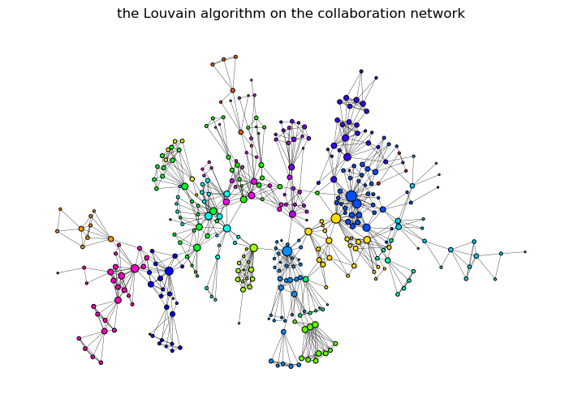

```python
netscience.graph['louvain'] = tuple(louvain(netscience).graph['louvain'].values())
for c, community in enumerate(netscience.graph['louvain']):
    for n in community: netscience.nodes[n]['louvain'] = c
cNum = c+1
netscience_plot('the Louvain algorithm on the collaboration network',
                [cmap(c/cNum) for n, c in netscience.nodes('louvain')])
print('Number of communities:', cNum)
```

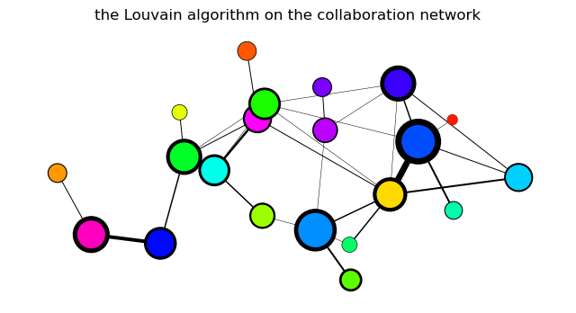

```python
netscience_louvain = community_network(netscience, 'louvain')
community_diagram(netscience_louvain,
                  'the Louvain algorithm on the collaboration network',
                  [cmap(c/cNum) for c in netscience_louvain])
```

## 4.3 Resolution limit

Although it is a useful approach in general, we must keep in mind that modularity maximization is **intrinsically misleading**. If a network has $E$ edges, a partition that has a total degree

\begin{align} K < \sqrt{2E} \end{align}

is easily merged with other similarly small partitions because the merge, as one can prove, certainly increases modularity. Consequently, small communities, which are perfectly physical and rational, are prohibited to exist just due to this purely mathematical restraint.

The restraint is also known as the "resolution limit" of modularity. You may read [Barabási's Chapter 9 (2016)](http://networksciencebook.com/chapter/9#modularity) if you want to know how it is derived.

# References

1. Barabási A.-L. (2016) *Network Science* (Cambridge Univeristy Press, Cambridge).
2. Blondel V. D., Guillaume J.-L., Lambiotte R., and Lefebvre E. (2008) *Fast unfolding of communities in large networks*, J. Stat. Mech. **2008**, P10008.
3. Clauset A., Newman M. E. J., and Moore C. (2004) *Finding community structure in very large networks*, Phys. Rev. E **70**, 066111.
4. De Nooy W., Mrvar A., and Batagelj V. (2005) *Exploratory Social Network Analysis with Pajek* (Cambridge University Press, Cambridge).
5. Fiedler M. (1973) *Algebraic connectivity of Graphs*, Czechoslov. Math. J. **23**, 298.
6. Girvan M. and Neman M. E. J. (2002) *Community structure in social and biological networks*, Proc. Natl. Acad. Sci. U.S.A. **99**, 7821.
7. Kernighan B. W. and Lin S. (1970) *An efficient heuristic procedure for partitioning graphs*, Bell Syst. Tech. J. **49** 291.
8. Lusseau D., Schneider K., Boisseau O. J., Haase P., Slooten E., and Dawson S. M. (2003) *The bottlenose dolphin community of Doubtful Sound features a large proportion of long-lasting associations*, Behav. Ecol. Sociobiol. **54** 396.
9. Newman M. E. J. (2004) *Fast algorithm for detecting community structure in networks*, Phys. Rev. E **69**, 066133.
10. Newman M. E. J. (2006) *Finding community structure in networks using the eigenvectors of matrices*, Phys. Rev. E **74**, 036104.
11. Ravasz E., Somera A. L., Mongru D. A., Oltvai Z. N., and Barabási A.-L. (2002) *Hierarchical Organization of Modularity in Metabolic Networks*, Science **297**, 1551.
12. Zachary W. W. (1977) *An Information Flow Model for Conflict and Fission in Small Groups*, J. Anthropol. Res. **33**, 452.